# Project: Investigate a Dataset - FBI Gun Data - Factors affecting Gun Ownership

- Introduction
- Data Wrangling
- Exploratory Data Analysis
- Conclusions

## Introduction

I have decided to chosen the US Census and Gun Dataset to perform my analysis on. I started by unzipping the provided zip file, converting the xlsx files to csv and then uploaded them to the workspace. The goal of this project is to find coorelation between the census data and the gun data.

My Hypothesis - There *have* to be certain factors which drive people towards wanting guns, and the census data must have some important variables which we can use to determine this. Due to the unclear and complicated nature of the dataset it is difficult to analyse all of the dependent variables and independent ones, however give below are some of the questions which I am trying to answer

- Is there any coorelation between population and gun ownership?
- Which are the top 5 states with the highest amount of guns per capita?
- Which are the top 5 states with the lowest amount of guns per capita?
- Is there a coorelation between number of veterans and gun ownership?
- Does poverty and gun ownership have a coorelation?

## Data Wrangling

Here, we have imported the required datasets. Next step would be to combine them into a single one to make analysis easier.

In the Gun Data - each row represents gun data for those specific months - I decided to combine this all into yearly basis to make it better correspond with the Census data which is year-ed.

```python
import pandas as pd
import numpy as np
from scipy import stats

%matplotlib inline

census_df = pd.read_csv('census_data.csv')
census_pop = dict(census_df.iloc[3][2:])
census_poverty = dict(census_df.iloc[49][2:])
census_veterans = dict(census_df.iloc[20][2:])


# Convert yyyy/mm to yyyy
dateparse = lambda dates: [pd.datetime.strptime(d, '%Y-%m') for d in dates]
gun_df = pd.read_csv('gun_data.csv', parse_dates=['month'], date_parser=dateparse)
gun_df['year'] = gun_df['month'].dt.year
gun_df_year = gun_df.groupby(['year','state']).sum()

# Create a combined dataset using the census and gun datasets
gun_by_state = gun_df_year.query('year == 2016').groupby(['state'])
for idx, row in gun_by_state:
    if idx in census_pop :
        gun_df_year.at[row.index,'population'] = census_pop[idx]
    if idx in census_poverty :
        gun_df_year.at[row.index,'poverty'] = census_poverty[idx]
    if idx in census_veterans :
        gun_df_year.at[row.index,'veterans'] = census_veterans[idx]


temp_df = gun_df_year.query('year == 2016')
```

### Data Cleaning

Now, that we have carefully combined the 2 datasets we can move aggregating the different columns to make things easier to analyse.

We remove all of the % and ',' symbols from the data, we drop the columns which we don't need and convert everything into usable datatypes.

We also take things a step further and delete all of the outliers from the data, after creating a copy of it with the outliers for future use.

```python
# Clean population column
temp_df['population'] = temp_df['population'].str.replace(',', '')
temp_df['poverty'] = temp_df['poverty'].str.replace('%', '')
temp_df['veterans'] = temp_df['veterans'].str.replace(',', '')
df = temp_df[['totals','population', 'poverty','veterans']]
df = df.reset_index()
df = df.drop(['year'], axis=1)
df = df.dropna(subset=['population','totals','poverty','veterans'])
df['population'] = df['population'].astype(int) # Converting to int
df['poverty'] = df['poverty'].astype(float) # Converting to float
df['veterans'] = df['veterans'].astype(float) # Converting to int
df_state = df
df = df.drop(['state'], axis=1)
df = df[(np.abs(stats.zscore(df)) < 3).all(axis=1)] # Remove outliers
```

## Exploratory Data Analysis

We could move to some EDA! You can see how each variable affects the results below.

```
<class 'pandas.core.frame.DataFrame'>
Int64Index: 47 entries, 0 to 54
Data columns (total 4 columns):
totals        47 non-null int64
population    47 non-null int64
poverty       47 non-null float64
veterans      47 non-null float64
dtypes: float64(2), int64(2)
memory usage: 1.8 KB
```

|  | totals | population | poverty | veterans |
| --- | --- | --- | --- | --- |
| 0 | 616947 | 4779736 | 17.1 | 363170.0 |
| 1 | 87647 | 710231 | 9.9 | 69323.0 |
| 2 | 416279 | 6392017 | 16.4 | 505794.0 |
| 3 | 266014 | 2915918 | 17.2 | 220953.0 |
| 5 | 540514 | 5029196 | 11.0 | 391725.0 |

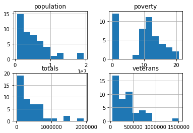

```python
df.info()
df.hist()
df.head()
```

```python
df.describe()
```

|  | totals | population | poverty | veterans |
| --- | --- | --- | --- | --- |
| count | 4.700000e+01 | 4.700000e+01 | 47.000000 | 4.700000e+01 |
| mean | 4.176555e+05 | 5.136275e+06 | 9.667000 | 3.503260e+05 |
| std | 4.043245e+05 | 4.467665e+06 | 6.247136 | 2.900993e+05 |
| min | 1.668100e+04 | 5.636260e+05 | 0.107000 | 4.470800e+04 |
| 25% | 1.421645e+05 | 1.696962e+06 | 3.749000 | 1.263145e+05 |
| 50% | 2.949070e+05 | 3.831074e+06 | 11.300000 | 2.958470e+05 |
| 75% | 5.905250e+05 | 6.515716e+06 | 13.900000 | 4.568780e+05 |
| max | 1.924070e+06 | 1.937810e+07 | 20.800000 | 1.507738e+06 |

```python
df.shape
```

```
(47, 4)
```

### Research Question 1 - Is there any coorelation between population and gun ownership?

#### Population vs Gun/capita

To compare the relation of guns to population we first calculate the guns to person ratio of the states, then we plot that and the population in a scatter plot.

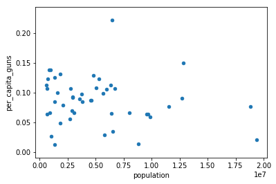

```python
df['per_capita_guns'] =  df['totals'] / df['population']
df = df.sort_values('per_capita_guns', axis=0, ascending=True, inplace=False)
df.plot(x='population', y='per_capita_guns', kind='scatter')
```

###### Answer

There is a weak corelation between the population and the number of guns.

It is apparent from the visualizations that scarely populated states seem to have more number of guns, and larger cities seem to have relatively lesser number of guns.

My reasoning for this is - in smaller states the settlements are usually away from each other, people might think that the response times for law enforcement are extremely high. To counter this they might believe that owning a gun would mean they could protect themselves and their families better. In more populated cities the law enforcement is able to respond more quickly hence people might feel less of a need for weapons.

### Research Question 2 - Does poverty and gun ownership have a coorelation?

#### Poverty vs Gun/capita

To compare the relation of guns to poverty percentages we plot the poverty and the per capita guns in a scatter plot.

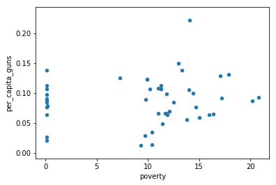

```python
df.plot(x='poverty', y='per_capita_guns', kind='scatter')
```

###### Answer

Inconclusive.

My reasoning was poverty would mean that there would be fewer guns, or atleast more wealth would mean fewer people would feel like they needed guns to feel safer or for protection. But this does not seem to be the case. Even with lower to no levels of poverty we can still see people buying guns and vice versa.

### Research Question 3 - Is there a coorelation between number of veterans and gun ownership?

#### Veterans vs Gun/capita

To compare the relation of guns to veterans we first calculate the veterans to person ratio of the states, then we plot that and the guns per capita on the scatter plot.

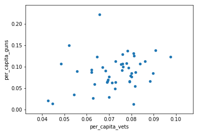

```python
df['per_capita_vets'] =  df['veterans'] / df['population']
df.plot(x='per_capita_vets', y='per_capita_guns', kind='scatter')
```

###### Answer

My reasoning for this was - Veterans have been in the special forces and know how to operate guns. Hence, they would surely be the target consumer base for guns, i.e More Vets, would mean more guns.

### Research Question 4 - Which are the top 5 states with the highest amount of guns per capita?

Here, we sort the states in the descending order to get the states with the most amount of guns.

```python
df_state['per_capita_guns'] =  df_state['totals'] / df_state['population']
df_state.sort_values('per_capita_guns', axis=0, ascending=False, inplace=False)[:5].head()
```

|  | state | totals | population | poverty | veterans | per_capita_guns |
| --- | --- | --- | --- | --- | --- | --- |
| 18 | Kentucky | 3676847 | 4339367 | 18.500 | 297312.0 | 0.847323 |
| 15 | Indiana | 1436725 | 6483802 | 14.100 | 426493.0 | 0.221587 |
| 14 | Illinois | 1924070 | 12830632 | 13.000 | 668933.0 | 0.149959 |
| 28 | Montana | 136337 | 989415 | 13.300 | 90000.0 | 0.137796 |
| 44 | South Dakota | 111921 | 814180 | 0.133 | 63742.0 | 0.137465 |

### Research Question 5 - Which are the top 5 states with the lowest amount of guns per capita?

Here, we sort the states in the ascending order to get the states with the least amount of guns.

```python
df_state.sort_values('per_capita_guns', axis=0, ascending=True, inplace=False)[:5].head()
```

|  | state | totals | population | poverty | veterans | per_capita_guns |
| --- | --- | --- | --- | --- | --- | --- |
| 12 | Hawaii | 16681 | 1360301 | 9.300 | 110238.0 | 0.012263 |
| 32 | New Jersey | 121853 | 8791894 | 10.400 | 393277.0 | 0.013860 |
| 34 | New York | 404772 | 19378102 | 0.147 | 828586.0 | 0.020888 |
| 42 | Rhode Island | 27758 | 1052567 | 0.128 | 66076.0 | 0.026372 |
| 22 | Maryland | 165367 | 5773552 | 9.700 | 403900.0 | 0.028642 |

## Conclusions

We can now summarise all our observations.

Gun ownership seems to be strongly driven more by emotion rather than any specific environmental factors. That being said, it does not mean that there are not quantifiable and measureable statistics for it.

Population and people who have had experience with guns before seem to be some of the driving forces for gun ownership. The Crime rate could also be an important factor affecting ownership but the linked dataset did not have any crime rate values.

```python
from subprocess import call
call(['python', '-m', 'nbconvert', 'Investigate_a_Dataset.ipynb'])
```

```
0
```